# Student Performance Analysis Using R

**Student:** Krutharth Aliwala  
**Enrollment Number:** 2505101200003

## 1. Introduction

This Tiny Project analyzes student academic performance using R. It follows the workflow demonstrated in Practicals 8, 9 and 10: CSV importing, data inspection, cleaning, statistical exploration, visualization, correlation and interpretation.

## 2. Objectives

- Import student data from CSV.
- Inspect and clean the dataset.
- Calculate median, variance and standard deviation.
- Analyze gender and result distributions.
- Create pie charts and bar plots.
- Measure correlation between attendance and marks.
- Interpret findings and conclude the analysis.

## 3. Database / Data Importing

```
student_data <- read.csv("Krutharth_Aliwala_Student_Performance.csv")
student_data
```

`read.csv()` imports the CSV file into R as a data frame.

## 4. Initial Data Inspection

```
head(student_data)
summary(student_data)
str(student_data)
```

These functions display the first records, descriptive summary and structure/data types.

## 5. Data Preprocessing and Cleaning

```
colSums(is.na(student_data))
sum(duplicated(student_data))
```

The dataset contains **no missing values** and **no duplicate records**, so no imputation or duplicate removal is necessary.

## 6. Statistical Exploration

```
median(student_data$Marks)
var(student_data$Marks)
sd(student_data$Marks)
```

**Mean:** 73.10  
**Median:** 74.50  
**Variance:** 209.46  
**Standard deviation:** 14.47

The mean and median are close, suggesting a reasonably balanced distribution of marks. The standard deviation indicates moderate variation in performance.

## 7. Gender Distribution

```
gender_count <- table(student_data$Gender)
pie(gender_count, main="Gender Distribution",
    labels=paste(names(gender_count), gender_count))
```

[figure not shown]

**Interpretation:** The dataset contains 10 male and 10 female students. The groups are equally represented.

## 8. Student Result Distribution

```
result_count <- table(student_data$Result)
pie(result_count, main="Student Result Distribution",
    labels=paste(names(result_count), result_count))
```

[figure not shown]

**Interpretation:** 20 of 20 students passed and 0 failed, giving a pass rate of 100.0%.

## 9. Student Marks Bar Plot

```
barplot(student_data$Marks,
        names.arg=student_data$Name,
        main="Student Marks",
        xlab="Students", ylab="Marks", las=2)
```

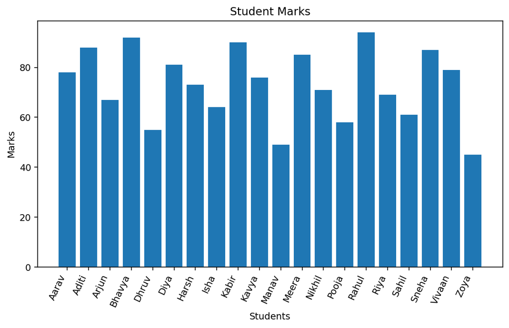

**Interpretation:** Marks range from 45 to 94, showing variation in academic performance.

## 10. Student Attendance Bar Plot

```
barplot(student_data$Attendance,
        names.arg=student_data$Name,
        main="Student Attendance",
        xlab="Students", ylab="Attendance (%)", las=2)
```

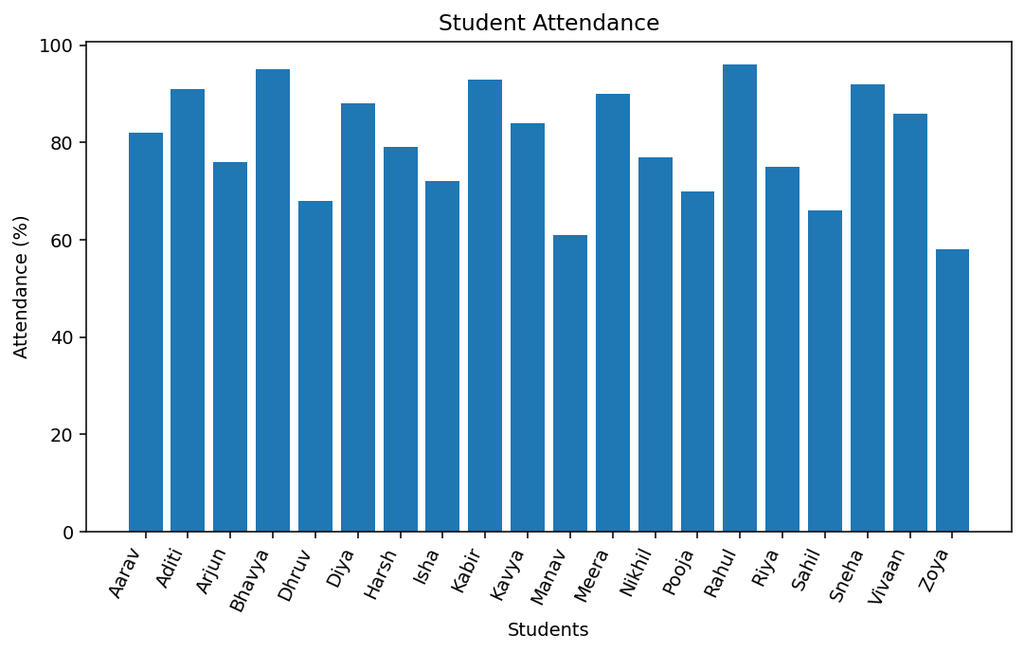

**Interpretation:** Attendance ranges from 58% to 96%.

## 11. Correlation Between Attendance and Marks

```
cor(student_data$Attendance, student_data$Marks)
```

**Pearson correlation coefficient: 0.990**

```
plot(student_data$Attendance, student_data$Marks,
     main="Attendance vs Marks",
     xlab="Attendance (%)", ylab="Marks", pch=19)
```

[figure not shown]

**Interpretation:** The correlation of 0.990 indicates a strong positive association in this sample: higher attendance generally corresponds to higher marks. Correlation indicates association, not causation.

## 12. Findings

1. The dataset contains 20 students with no missing or duplicate records.
2. The average mark is 73.10; the median is 74.50.
3. The standard deviation is 14.47, indicating moderate variation.
4. The pass rate is 100.0%.
5. Male and female students are equally represented.
6. Attendance and marks have a correlation of 0.990, showing a strong positive association.

## 13. Conclusion

This Tiny Project demonstrated a complete student-performance data-analysis workflow. The CSV data was imported and inspected, data quality was checked, statistical measures were calculated, and multiple visualizations were created. The analysis suggests that attendance is positively associated with marks in this sample. R provides an effective way to convert raw student records into statistical insights and visual evidence.

## 14. Complete Dataset

| Name | Gender | Marks | Attendance | Result |
| --- | --- | --- | --- | --- |
| Aarav | Male | 78 | 82 | Pass |
| Aditi | Female | 88 | 91 | Pass |
| Arjun | Male | 67 | 76 | Pass |
| Bhavya | Female | 92 | 95 | Pass |
| Dhruv | Male | 55 | 68 | Pass |
| Diya | Female | 81 | 88 | Pass |
| Harsh | Male | 73 | 79 | Pass |
| Isha | Female | 64 | 72 | Pass |
| Kabir | Male | 90 | 93 | Pass |
| Kavya | Female | 76 | 84 | Pass |
| Manav | Male | 49 | 61 | Pass |
| Meera | Female | 85 | 90 | Pass |
| Nikhil | Male | 71 | 77 | Pass |
| Pooja | Female | 58 | 70 | Pass |
| Rahul | Male | 94 | 96 | Pass |
| Riya | Female | 69 | 75 | Pass |
| Sahil | Male | 61 | 66 | Pass |
| Sneha | Female | 87 | 92 | Pass |
| Vivaan | Male | 79 | 86 | Pass |
| Zoya | Female | 45 | 58 | Pass |